# Statistical Modeling and Graphing

Jesus Wladimir Avalos Quizhpi

2024-02-13

*Citation*: Trends in Internet-based business-to-business marketing

*Abstract*: The Internet is changing the transactional paradigms under which businesses-to-business marketers operate. Business-to-business marketers that take advantage of the operational efficiencies and effectiveness that emerge from utilizing the Internet in transactions are out performing firms that utilize traditional transactional processes. As an example, Dell computers, by utilizing business-to-business processes that take advantage of the Internet, has gained the largest market share in the PC business when compared to traditional manufacturers such as Compaq. This paper first examines the genesis of the Internet movement in business-to-business markets. The long-term impact of the increase of business-to-business utilization of the Internet on the marketing theory and marketing process is then discussed. Finally, managerial implications and directions for future research are highlighted.

Dataset includes:

1. Business marketing focus - traditional or forward thinking.
2. Internet use - low, medium, or high levels of business marketing use on the internet.
3. Time _ 1 - sales scores at the first measurement time.
4. Time _ 2 - sales scores at the second measurement time

On all of these questions, be sure to include a coherent label for the X and Y axes. You should change them to be “professional looking” (i.e. Proper Case, explain the variable listed, and could be printed in a journal). The following will be assessed:

1. Is it readable?
2. Is X-axis labeled appropriately?
3. Is Y-axis labeled appropriately?
4. Is it the right graph?
5. Do the labels in the legend look appropriate?
6. Are there error bars when appropriate?

We won’t grade for color of bars or background color, but you should consider that these things are usually printed in black/white - so be sure you know how to change those values as well as get rid of that grey background.

Please note that each subpoint (i.e. a, b) indicates a different chart.

```r
getwd()
```

```
## [1] "C:/Users/jwava/OneDrive - Harrisburg University/HU/1st Semester_Spring2024/ANLY 500 -51-A 2024Spring - Analytics I Principles & Applications/Assignments/Assignment 04 05 - Lab Graphing"
```

```r
# Load the dataset in csv format
dataset <- read.csv("05_data.csv", header = TRUE)

# First rows of the dataset
head(dataset)
```

```
##     id biz_focus internet   time.1    time.2
## 1 S001   forward     high 7.544619  9.711458
## 2 S002   forward     high 7.566022 10.237006
## 3 S003   forward     high 5.930514  9.183059
## 4 S004   forward     high 6.773251 10.495166
## 5 S005   forward     high 7.621748  8.689356
## 6 S006   forward     high 8.107049 10.265340
```

```r
# Structure of the dataset
str(dataset)
```

```
## 'data.frame':    300 obs. of  5 variables:
##  $ id       : chr  "S001" "S002" "S003" "S004" ...
##  $ biz_focus: chr  "forward" "forward" "forward" "forward" ...
##  $ internet : chr  "high" "high" "high" "high" ...
##  $ time.1   : num  7.54 7.57 5.93 6.77 7.62 ...
##  $ time.2   : num  9.71 10.24 9.18 10.5 8.69 ...
```

```r
# Variables in the dataset
names(dataset)
```

```
## [1] "id"        "biz_focus" "internet"  "time.1"    "time.2"
```

1. Make a simple histogram using ggplot:
   1. Sales at time 1

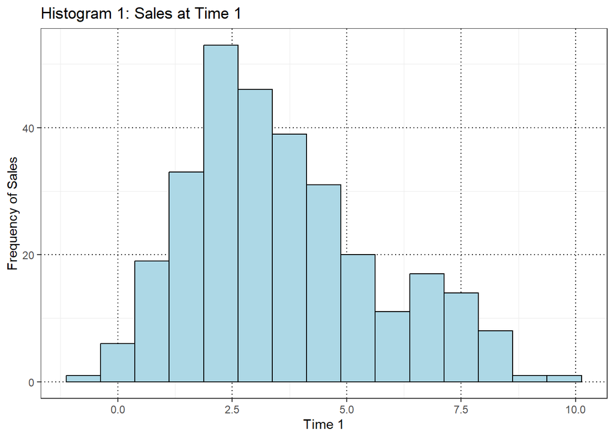

```
b.  Sales at time 2
```

```r
# Load libraries for Data Visualization
library(ggplot2)

# Histogram of sales at time 1
hist1 <- ggplot(dataset, aes(x = time.1)) +
  geom_histogram(binwidth = 0.75, fill = "lightblue", color = "black") +
  labs(title = "Histogram 1: Sales at Time 1", x = "Time 1", y = "Frequency of Sales") +
  theme_bw() +
  theme(panel.grid.major = element_line(color = "black", linetype = "dotted"))

hist1
```

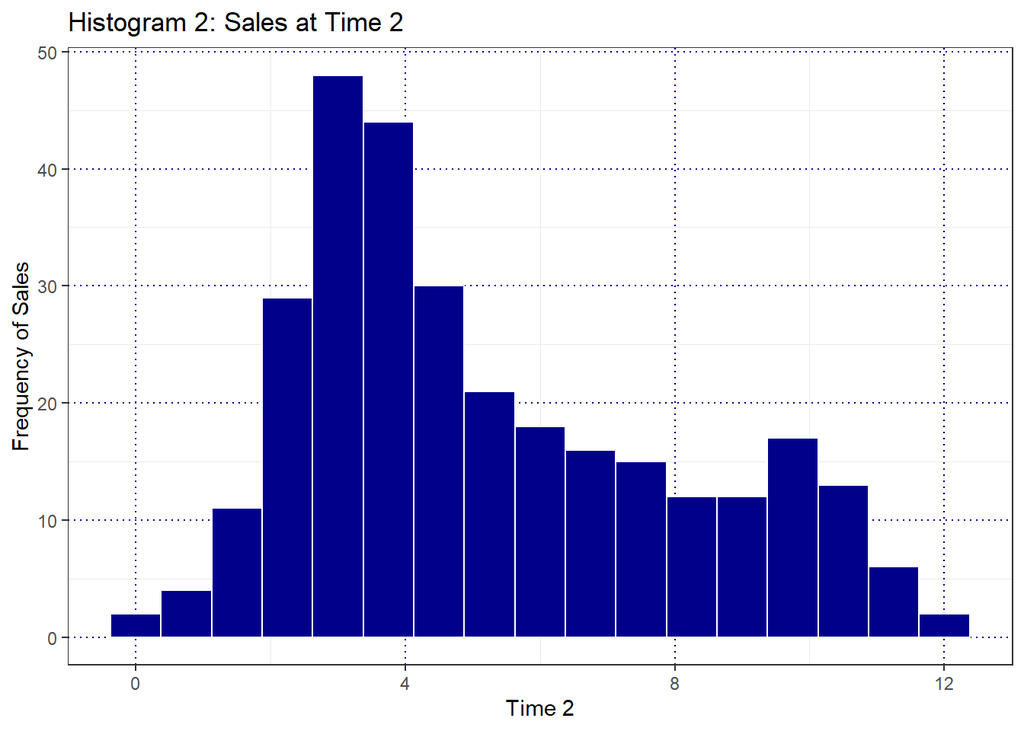

```r
# Histogram of sales at time 1
hist2 <- ggplot(dataset, aes(x = time.2)) +
  geom_histogram(binwidth = 0.75, fill = "darkblue", color = "white") +
  labs(title = "Histogram 2: Sales at Time 2", x = "Time 2", y = "Frequency of Sales") +
  #theme(panel.border = element_rect(color = "black", fill = NA),
  #      panel.background = element_rect(fill = "White"),
  #      panel.grid.major = element_line(color = "grey", linetype = "dotted"))
  theme_bw() +
  theme(panel.grid.major = element_line(color = "darkblue", linetype = "dotted"))

hist2
```

2. Make a bar chart with two independent variables:
   1. Business focus, internet, DV: sales at time 2

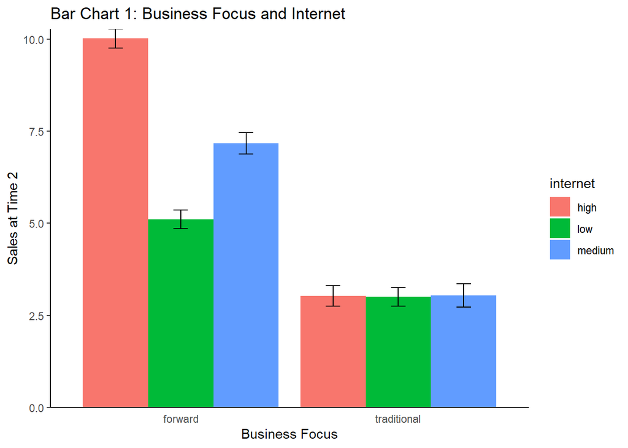

```r
# Bar chart: Business focus and internet - DV: Sales at time 2
barchart1 <- ggplot(dataset, aes(x = biz_focus, fill = internet, y = time.2)) +
  stat_summary(fun.y = "mean", geom = "bar", position = "dodge") +
  stat_summary(fun.data = "mean_cl_normal", geom = "errorbar", position = position_dodge(width = 0.90), width = 0.2) +
  labs(title = "Bar Chart 1: Business Focus and Internet", x = "Business Focus", y = "Sales at Time 2") +
  scale_y_continuous(expand = c(0, 0)) +  # Set y-axis to start at 0
  theme_classic() +
  theme(axis.ticks.x = element_blank())  # Remove x-axis ticks

barchart1
```

3. Make a bar chart with two independent variables:
   1. Time (time 1, time 2), Business focus, DV: is sales from time 1 and 2

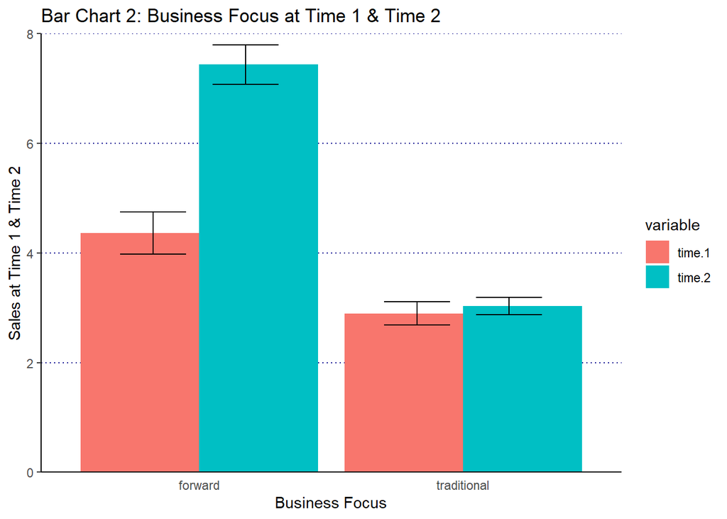

```r
# Package to melt the dataset
library(reshape)

# Melt Data with Time.1 and Time.2
meltdata <- melt(dataset, id.vars = c("biz_focus"), measure.vars = c("time.1", "time.2"))

# Bar chart: Time, Business focus - DV: Sales at time 1 and 2
barchart2 <- ggplot(meltdata, aes(x = biz_focus, y = value, fill = variable)) +
  stat_summary(fun.y = "mean", geom = "bar", position = "dodge") +
  stat_summary(fun.data = "mean_cl_normal", geom = "errorbar", position = position_dodge(width = 0.70), width = 0.5) +
  labs(title = "Bar Chart 2: Business Focus at Time 1 & Time 2", x = "Business Focus", y = "Sales at Time 1 & Time 2") +
  scale_y_continuous(expand = c(0, 0)) +  # Set y-axis to start at 0
  coord_cartesian(ylim = c(0, 8)) +
  theme_classic() +
  theme(axis.ticks.x = element_blank(), # Remove x-axis ticks
        panel.grid.major.y = element_line(color = "darkblue", linetype = "dotted"))

barchart2
```

4. Make a simple line graph:
   1. Time (time 1, time 2), DV: is sales from time 1 and 2

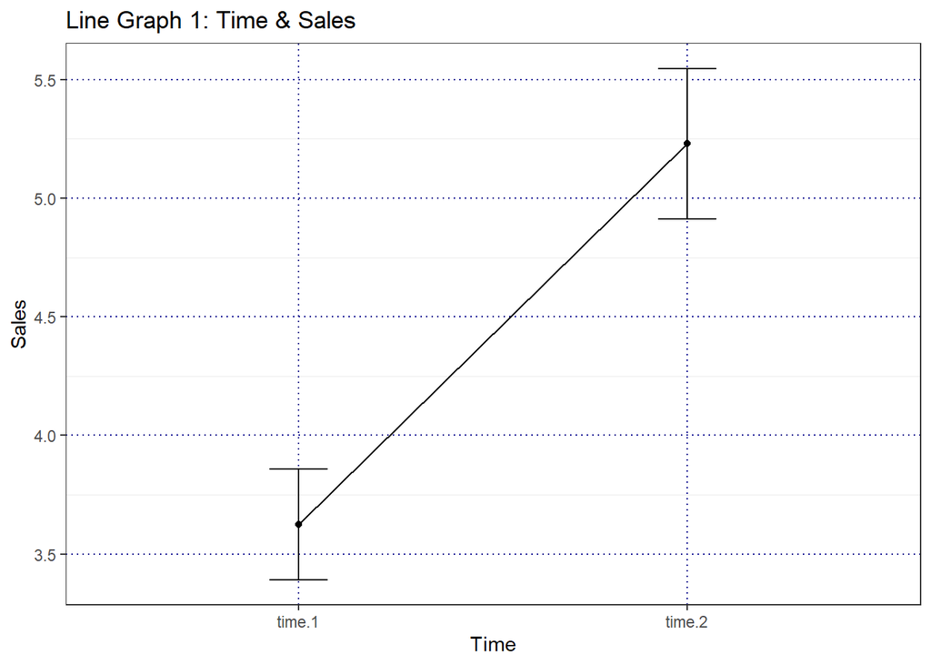

```r
# Line graph: Time, Sales at time 1 and 2
linegraph1 <- ggplot(meltdata, aes(x = variable, y = value)) +
  stat_summary(fun.y = "mean", geom = "point") +
  stat_summary(fun.y = "mean", geom = "line", aes(group = 1)) +
  stat_summary(fun.data = "mean_cl_normal", geom = "errorbar", width = 0.15) +
  labs(title = "Line Graph 1: Time & Sales", x = "Time", y = "Sales") +
  theme_bw() +
  theme(panel.grid.major = element_line(color = "darkblue", linetype = "dotted"))


linegraph1
```

5. Make a simple scatterplot:
   1. Sales at Time 1, Time 2

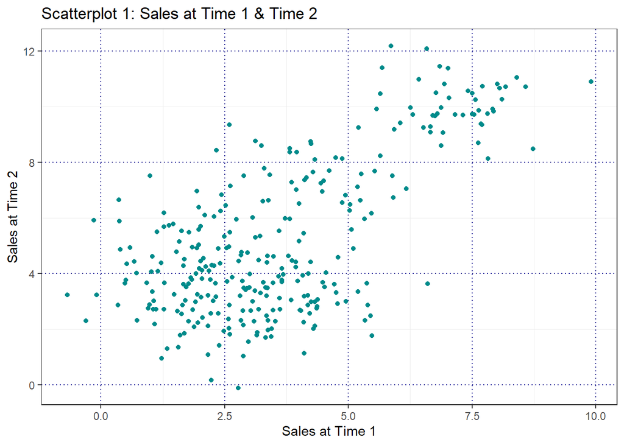

```r
# Scatterplot1: Sales at time 1 and 2
scatter1 <- ggplot(dataset, aes(x = time.1, y = time.2)) +
  geom_point(color = "darkcyan") +
  labs(title = "Scatterplot 1: Sales at Time 1 & Time 2", x = "Sales at Time 1", y = "Sales at Time 2") +
  theme_bw() +
  theme(panel.grid.major = element_line(color = "darkblue", linetype = "dotted"))

scatter1
```

6. Make a grouped scatterplot:
   1. Sales at time 1 and 2, Business focus

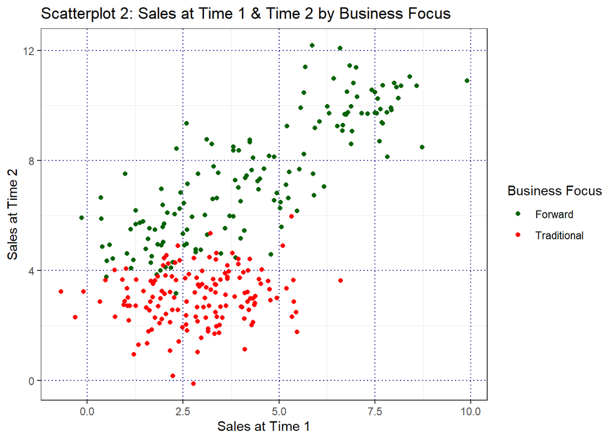

```r
# Scatterplot2: Sales at time 1 and 2, Business focus
scatter2 <- ggplot(dataset, aes(x = time.1, y = time.2, color = biz_focus)) +
  geom_point(size = 1.5) +
  labs(title = "Scatterplot 2: Sales at Time 1 & Time 2 by Business Focus", x = "Sales at Time 1", y = "Sales at Time 2", color = "Business Focus") +
  scale_color_manual(values = c("darkgreen", "red"),
                     labels = c("Forward", "Traditional")) +
  theme_bw() +
  theme(panel.grid.major = element_line(color = "darkblue", linetype = "dotted"))

scatter2
```